# OurCity Colombia - Screening phase data

Diseño Público

7/28/2021

# Contenido

## Framework

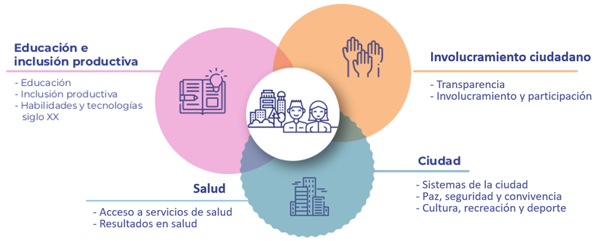

## Sistemas de ciudad

### Ranking

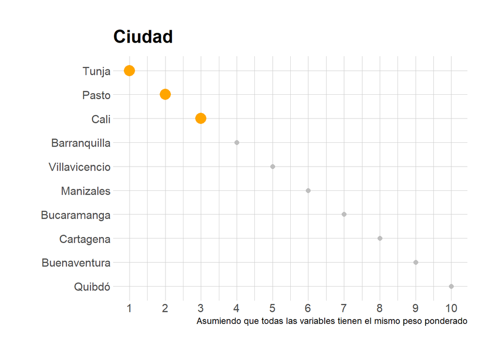

### Variables estudiadas

#### Sistemas de ciudad

- Optimismo respecto al futuro de la ciudad
- Índice de ciudades modernas
- Índice de desarrollo humano
- Satisfacción con la gestión global de la Alcaldía
- Infraestructura de servicios y vivienda
- Índice de ciudades universitarias
- Aparición en rankings internacionales para la inversión extranjera

#### Paz, seguridad y convivencia

- Índice de seguridad y justicia
- Jóvenes víctimas
- Violencia interpersonal
- Violencia intrafamiliar

#### Cultura, recreación y deporte

- Índice de oferta cultural
- Metas de planes de desarrollo con atenciones a sectores culturales, recreativos o de deporte

## Educación e inclusión productiva

### Ranking

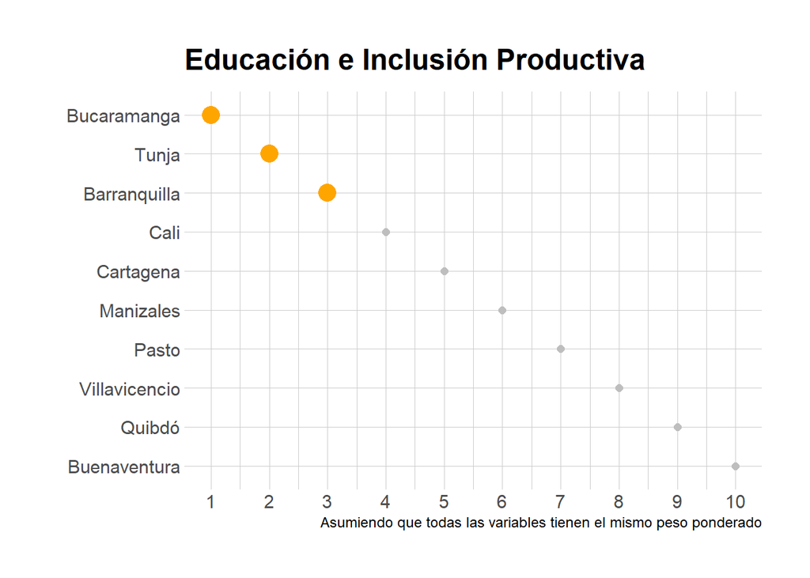

### Variables estudiadas

#### Educación

- Tasa de deserción intra-anual del sector oficial en educación básica y media (Desde transición hasta once)
- Tasa de repitencia del sector oficial en educación básica y media (Desde transición hasta once)
- Cobertura neta en educación - Total
- Cobertura neta en educación secundaria
- Cobertura neta en educación media
- Promedio del puntaje global - Prueba Saber 11
- Matriculados en educación superior
- Cobertura en educación superior
- Graduados en educación superior

#### Inclusión productiva

- % de población jóven en edad de trabajar
- Tasa general de participación juvenil
- Tasa de desempleo juvenil
- Total de jóvenes NINI (de 14 a 28 años)
- Proporción de jóvenes entre 14 y 28 años beneficiaria del programa jóvenes en accción
- Empresas nuevas creadas
- Proporción de personas que perdieron un empleo por causa de la pandemia
- Proporción de personas que manifiestan que en su hogar los ingresos no alcanzan para cubrir gastos mínimos

#### Habilidades y tecnologías para el siglo XXI

- Infraestructura TIC
- Capacidades TIC
- Investigación de alta calidad
- Registros de propiedad industrial
- Sofisticación de negocios
- Producción de conocimiento y tecnología
- Producción creativa

## Involucramiento ciudadano

### Ranking

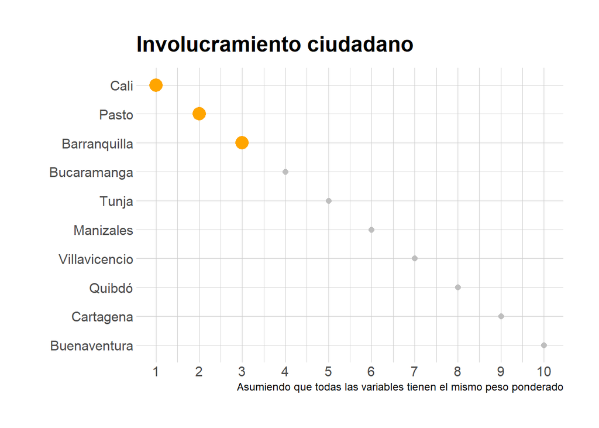

### Variables estudiadas

#### Transparencia

- Índice de transparencia
- Índice de Gobierno Digital para la Sociedad
- Porcentaje de procesos de contratación en Secop II

#### Involucramiento y participación

- Mecanismos e instancias de participación
- Conocimiento de mecanismos de participación
- Metas de los planes de desarrollo con atenciones directas a jóvenes
- Espacios de participación informales rastreados por medio de redes sociales y prensa

> Nota: los datos de involucramiento y participación no son comparables, luego el ranking presentado solo tiene en cuenta las variables de transparencia.

## Salud

### Ranking

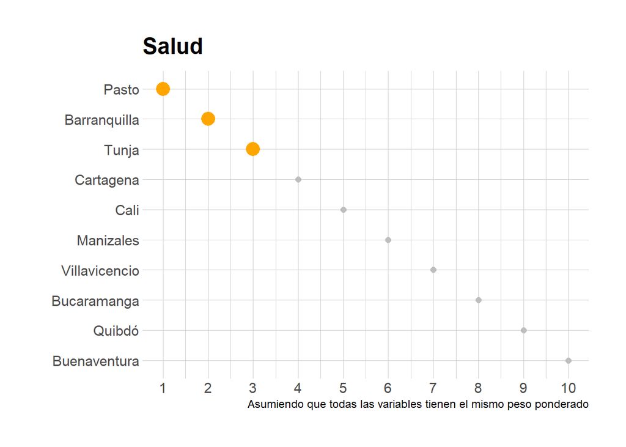

### Variables estudiadas

#### Acceso a servicios de salud

- Índice de acceso a salud
- Índice de capacidades en salud

#### Resultados en salud

- Mortalidad infantil
- Índice de desnutrición crónica - Categoría municipal

## Preselección

Supuestos de trabajo:

1. Todas las categorías tienen el mismo peso (25% cada una)
2. Todas las subcategorías tienen el mismo peso
3. Todas las variables dentro de cada subcategoría tienen el mismo peso

Con esta configuración de factores, se tiene la siguiente priorización de ciudades:

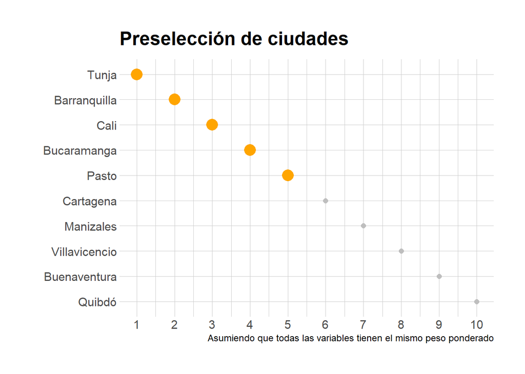

# Limitaciones

Si bien hay múltiples bases de datos con información para jóvenes entre los catorce y veintiocho años, ninguna es representativa en específico de este segmento poblacional, por lo cual no hay una fuente única, que permita comparaciones y que ofrezca información que permita caracterizar y describir la situación de los jóvenes en el país.

Por lo anterior, se tienen múltiples fuentes de información para analizar brechas en diversas dimensiones de los jóvenes, no obstante, dichos análisis tienen fuertes limitaciones por la poca comparabilidad de las mediciones e indicadores y por no representar completamente al segmento poblacional de los jóvenes.

# Acceso a microdatos

Como parte integral de la entrega de los productos contractuales, se tiene consolidada una sábana de datos que fue construida a partir de las diversas fuentes de información secundaria.

Los datos pueden ser consultados **[a través de este enlace de Google Drive](https://drive.google.com/file/d/1Ea5VqcvIQaTdtUzRTZ7jhHnXr62djSQC/view?usp=sharing)**.

[figure not shown]